```
Loading data...
```

```
C:\Users\nils\OneDrive - Universität Zürich UZH\Dokumente 1\1_PhD\5_CHAPTER1\paper\github\code\analysis\FigFunctions.py:810: RuntimeWarning: invalid value encountered in true_divide
  return ((NIR - RED) / (NIR + RED))
```

```
Data for this site is available. Loading ...
done.
```

```
C:\Users\nils\OneDrive - Universität Zürich UZH\Dokumente 1\1_PhD\5_CHAPTER1\paper\github\code\analysis\FigFunctions.py:810: RuntimeWarning: invalid value encountered in true_divide
  return ((NIR - RED) / (NIR + RED))
```

```
Data for this site is available. Loading ...
done.
```

```
C:\Users\nils\OneDrive - Universität Zürich UZH\Dokumente 1\1_PhD\5_CHAPTER1\paper\github\code\analysis\FigFunctions.py:810: RuntimeWarning: invalid value encountered in true_divide
  return ((NIR - RED) / (NIR + RED))
```

```
Data for this site is available. Loading ...
done.
```

# Relationship NDVI vs. LST

We would generally expect to see a negative relation between NDVI and LST, i.e., higher NDVI has cooler LST. Nill et al. (2019) have found negative relations between NDVI and LST form Landsat in the Mackenzie river delta (see 2nd column in Figure below):

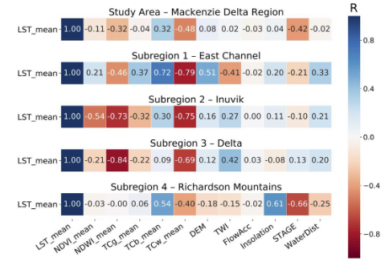

### Cloudberry hills

Here, we see that:

1. This negative relation holds for most plant communities.
2. Lichen-dominated high-centered polygon communities (HP1) and tops of the low-centered wetland polygon complexes (LW2) show a positive correlation.

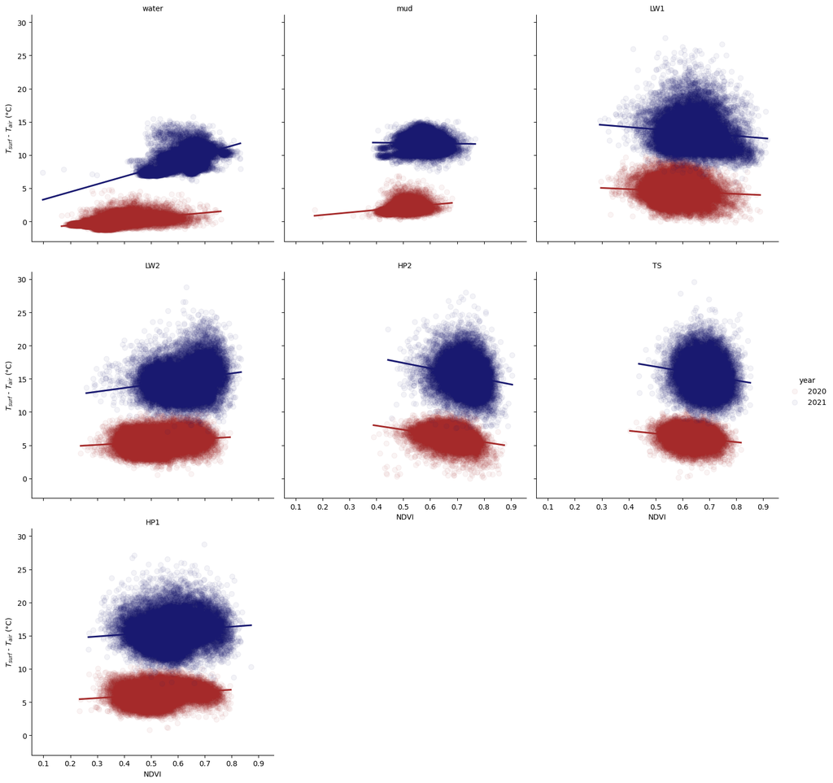

The positive correlation between NDVI and $\Delta T_{surf-air}$ for the HP1 and LW2 communities is really interesting, because I expected that when Lichen-dominated patches have low NDVI and high $\Delta T_{surf-air}$ the more mixed communities with higher NDVI have stronger land surface cooling. I suspect they may be linked to the exposed topographical position and abundance of ledum which probably has a high NDVI but weak cooling effect.

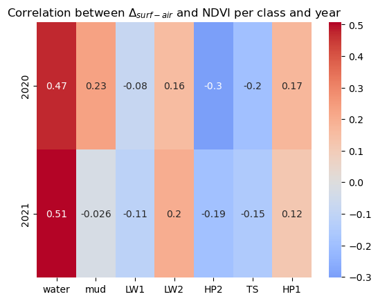

Here, I show the topographical position index of the 2020 data.

- positive TPI = this spot is elevated compared to its surroundings (in a 5 x 5m area)
- negative TPI = this spot sits below the average elevation of its surroundings

We can see that a TPI is positively correlated with NDVI. Likely, the topographical position isn't a decisive factor why the NDVI and land surface cooling in LW2 and HP1 communities show a positive correlation while in the other communities they are negatively correlated.

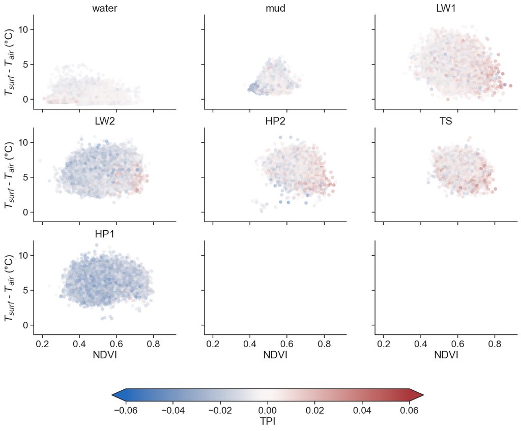

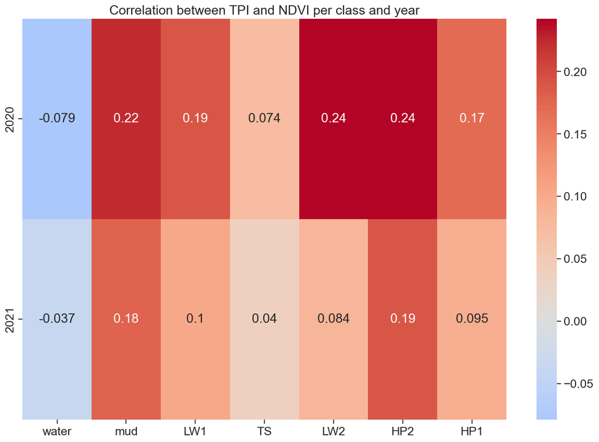